# Time Series Analysis and Model Diagnostics

### ACF Plot for Simulated ARMA(1,1) Process

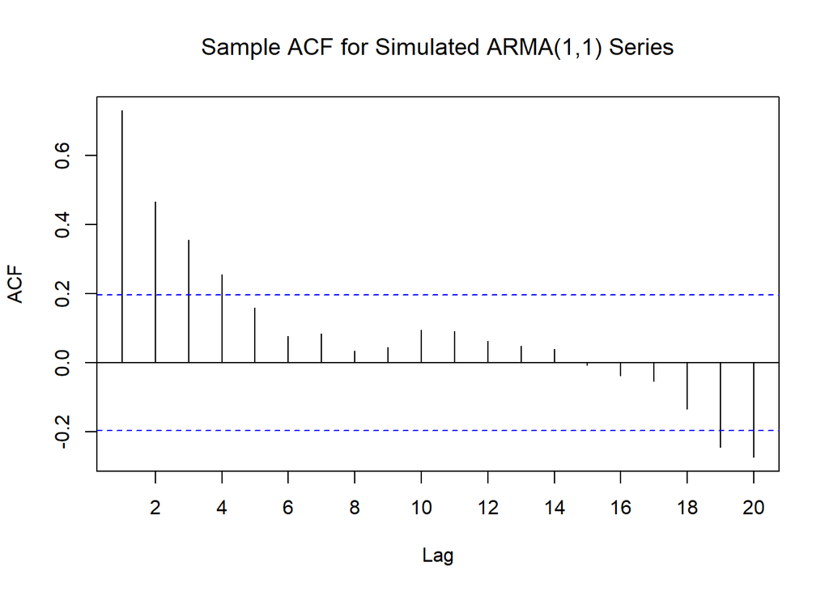

```r
data(arma11.s)
acf(arma11.s, xaxp=c(0,20,10),
main = expression("Sample ACF for Simulated ARMA(1,1) Series"))
```

The autocorrelation function (ACF) plot displays the sample autocorrelations of the simulated ARMA(1,1) process defined by $\displaystyle Y_t = \theta_1 Y_{t-1} + Z_t + \theta_2 Z_{t-1}$, where $\theta_1 = 0.6$, $\theta_2 = -0.3$, and $Z_t$ is white noise. In contrast to pure AR or MA processes, the ACF of an ARMA(1,1) process exhibits a hybrid decay pattern. The plot begins with a strong positive spike at lag 1, followed by a gradual decline across subsequent lags. This tapering pattern is influenced by the interplay between the autoregressive memory introduced by $\theta_1$ and the moving average smoothing from $\theta_2$. Notably, the autocorrelations remain above the confidence bounds for several early lags before eventually settling within them, reflecting the persistent but fading influence of past observations and noise. A unique trait of this sample is the minor negative bias in later lags (around lags 18–20), which may stem from sampling variability or the specific realization of the noise process.

### PACF Plot for Simulated ARMA(1,1) Process

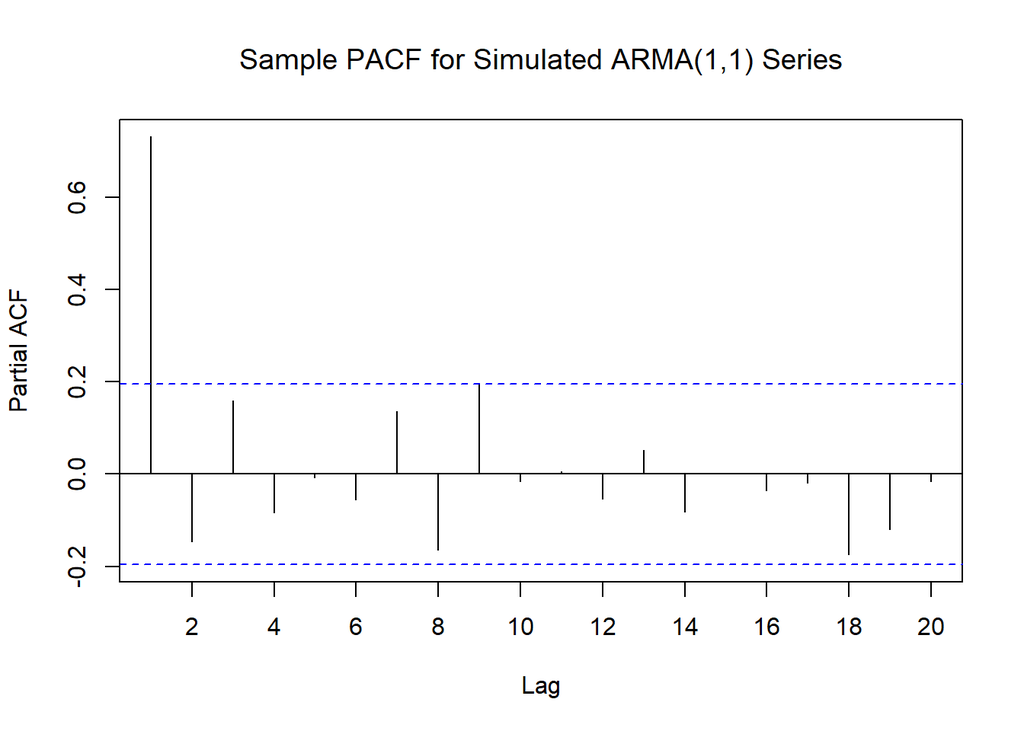

```r
data(arma11.s)
pacf(arma11.s, xaxp=c(0,20,10),
main = expression("Sample PACF for Simulated ARMA(1,1) Series"))
```

The partial autocorrelation function (PACF) plot presents the sample partial autocorrelations for a simulated ARMA(1,1) process defined by $\displaystyle Y_t = \theta_1 Y_{t-1} + Z_t + \theta_2 Z_{t-1}$, with $\theta_1 = 0.6$, $\theta_2 = -0.3$, and $Z_t$ representing white noise. Unlike AR or MA models where PACF patterns are more sharply defined, the ARMA(1,1) process typically produces a more diffuse structure. This plot reveals a strong spike at lag 1, indicating a dominant direct dependence with the first prior observation, followed by minor, statistically insignificant spikes at higher lags that remain within the 95% confidence bounds. The gradual decay beyond lag 1, without a clean cutoff or sinusoidal behavior, reflects the blended structure of AR and MA components. A subtle distinguishing characteristic in this sample is the mild elevation at lags 3 and 9, which—while not significant—adds slight irregularity to an otherwise stable PACF pattern.

```r
data(arma11.s)
eacf(arma11.s)
```

```
## AR/MA
##   0 1 2 3 4 5 6 7 8 9 10 11 12 13
## 0 x x x x o o o o o o o  o  o  o
## 1 x o o o o o o o o o o  o  o  o
## 2 x o o o o o o o o o o  o  o  o
## 3 x x o o o o o o o o o  o  o  o
## 4 x o x o o o o o o o o  o  o  o
## 5 x o o o o o o o o o o  o  o  o
## 6 x o o o x o o o o o o  o  o  o
## 7 x o o o x o o o o o o  o  o  o
```